# Chapter 2: Regression analysis

```r
#reading the data
date()
```

```
## [1] "Fri Nov 11 14:18:33 2022"
```

```r
library(tidyverse)
students2014 <- read.table("https://raw.githubusercontent.com/KimmoVehkalahti/Helsinki-Open-Data-Science/master/datasets/learning2014.txt", sep=",", header=TRUE)
#an option would be open the .csv file from the directory by activating this chunk: student2014 <- read_csv("./data/learning2014.csv")
```

## About the dataset

This dataset was originally created from data that is collected from students attending the course Johdatus yhteiskuntatieteeseen in the fall of 2014. 183 of the 250 students attendint the course participated in the study. Due to some missing data, there are only 166 participants in the final dataset.

The original data that this current dataset was created from can be found here: https://raw.githubusercontent.com/KimmoVehkalahti/Helsinki-Open-Data-Science/master/datasets/learning2014.txt

This current dataset has only 7 variables: gender, age, attitude, deep, stra, surf and points. Combination variables in the original data (stra, deep, surf) have been scaled to the original scales by taking the mean.

Attitude tells about students overall attitude towards statistics and has also been scaled back to the original scale by dividing it with the total number of questions.

Points tells the exam points. Observations with zero points have been removed, because these students did not attend the exam.

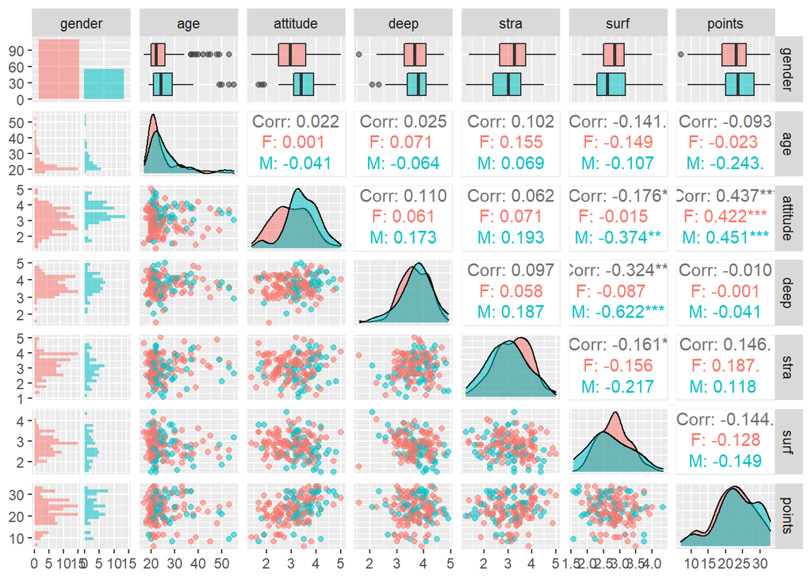

```r
# access the GGally and ggplot2 libraries
library(GGally)
library(ggplot2)
library(dplyr)

# create a more advanced plot matrix that shows the graphical overview of the data
p <- ggpairs(students2014, mapping = aes(col = gender, alpha = 0.3), lower = list(combo = wrap("facethist", bins = 20)))
p
```

```r
#Summaries of the variables

summary.factor(students2014$gender)
```

```
##   F   M
## 110  56
```

```r
summary(students2014$age)
```

```
##    Min. 1st Qu.  Median    Mean 3rd Qu.    Max.
##   17.00   21.00   22.00   25.51   27.00   55.00
```

```r
summary(students2014$attitude)
```

```
##    Min. 1st Qu.  Median    Mean 3rd Qu.    Max.
##   1.400   2.600   3.200   3.143   3.700   5.000
```

```r
summary(students2014$deep)
```

```
##    Min. 1st Qu.  Median    Mean 3rd Qu.    Max.
##   1.583   3.333   3.667   3.680   4.083   4.917
```

```r
summary(students2014$stra)
```

```
##    Min. 1st Qu.  Median    Mean 3rd Qu.    Max.
##   1.250   2.625   3.188   3.121   3.625   5.000
```

```r
summary(students2014$surf)
```

```
##    Min. 1st Qu.  Median    Mean 3rd Qu.    Max.
##   1.583   2.417   2.833   2.787   3.167   4.333
```

```r
summary(students2014$points)
```

```
##    Min. 1st Qu.  Median    Mean 3rd Qu.    Max.
##    7.00   19.00   23.00   22.72   27.75   33.00
```

##Describtion of the variables

There are 110 females and 56 males. The mean age of the students is 25,5 years. The youngest student is 17 and oldeset one is 55 y.o.

The mean attitude is 3.1 (range 1.4-5.0). The mean for deep learning is 3.7 (range 1.6-4.9), the mean for strategic learning is 3.1 (range 1.3-5.0) and the mean for surface learning is 2.8 (range 1.6-4.3).

The mean exam points was 22.7 (range 7.0-33.0).

```r
#choose three variables as explanatory variables and fit a regression model where exam points is the target (dependent, outcome) variable. Show a summary of the fitted model

# create a regression model with multiple explanatory variables
my_model <- lm(points ~ attitude + stra + surf, data = students2014)

# print out a summary of the model
summary(my_model)
```

```
##
## Call:
## lm(formula = points ~ attitude + stra + surf, data = students2014)
##
## Residuals:
##      Min       1Q   Median       3Q      Max
## -17.1550  -3.4346   0.5156   3.6401  10.8952
##
## Coefficients:
##             Estimate Std. Error t value Pr(>|t|)
## (Intercept)  11.0171     3.6837   2.991  0.00322 **
## attitude      3.3952     0.5741   5.913 1.93e-08 ***
## stra          0.8531     0.5416   1.575  0.11716
## surf         -0.5861     0.8014  -0.731  0.46563
## ---
## Signif. codes:  0 '***' 0.001 '**' 0.01 '*' 0.05 '.' 0.1 ' ' 1
##
## Residual standard error: 5.296 on 162 degrees of freedom
## Multiple R-squared:  0.2074, Adjusted R-squared:  0.1927
## F-statistic: 14.13 on 3 and 162 DF,  p-value: 3.156e-08
```

```r
#trying to find significant variables
my_model2 <- lm(points ~ attitude + stra, data = students2014)
summary(my_model2)
```

```
##
## Call:
## lm(formula = points ~ attitude + stra, data = students2014)
##
## Residuals:
##      Min       1Q   Median       3Q      Max
## -17.6436  -3.3113   0.5575   3.7928  10.9295
##
## Coefficients:
##             Estimate Std. Error t value Pr(>|t|)
## (Intercept)   8.9729     2.3959   3.745  0.00025 ***
## attitude      3.4658     0.5652   6.132 6.31e-09 ***
## stra          0.9137     0.5345   1.709  0.08927 .
## ---
## Signif. codes:  0 '***' 0.001 '**' 0.01 '*' 0.05 '.' 0.1 ' ' 1
##
## Residual standard error: 5.289 on 163 degrees of freedom
## Multiple R-squared:  0.2048, Adjusted R-squared:  0.1951
## F-statistic: 20.99 on 2 and 163 DF,  p-value: 7.734e-09
```

```r
#still fixing the model
my_model3 <- lm(points ~ attitude, data = students2014)
summary(my_model3)
```

```
##
## Call:
## lm(formula = points ~ attitude, data = students2014)
##
## Residuals:
##      Min       1Q   Median       3Q      Max
## -16.9763  -3.2119   0.4339   4.1534  10.6645
##
## Coefficients:
##             Estimate Std. Error t value Pr(>|t|)
## (Intercept)  11.6372     1.8303   6.358 1.95e-09 ***
## attitude      3.5255     0.5674   6.214 4.12e-09 ***
## ---
## Signif. codes:  0 '***' 0.001 '**' 0.01 '*' 0.05 '.' 0.1 ' ' 1
##
## Residual standard error: 5.32 on 164 degrees of freedom
## Multiple R-squared:  0.1906, Adjusted R-squared:  0.1856
## F-statistic: 38.61 on 1 and 164 DF,  p-value: 4.119e-09
```

##Interpretation of the multiple regression analysis

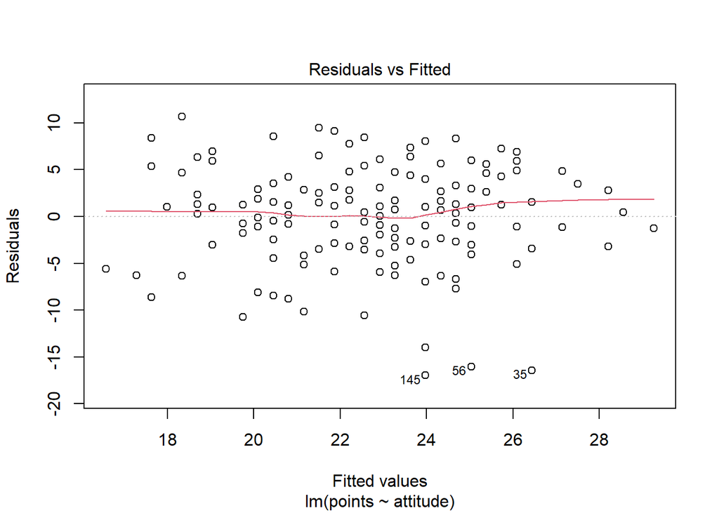

```r
#Producing the following diagnostic plots: Residuals vs Fitted values, Normal QQ-plot and Residuals vs Leverage

plot(my_model3, which = 1)
```

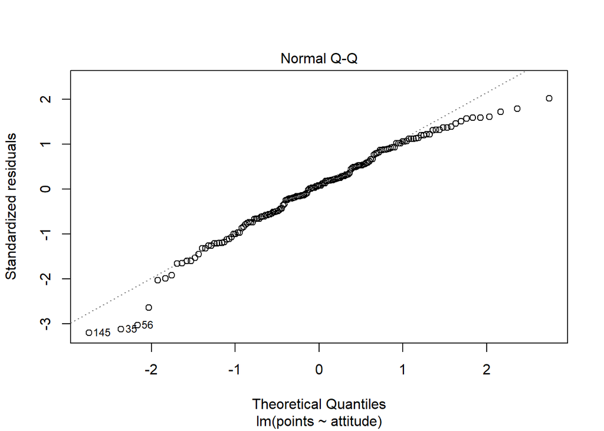

```r
plot(my_model3, which = 2)
```

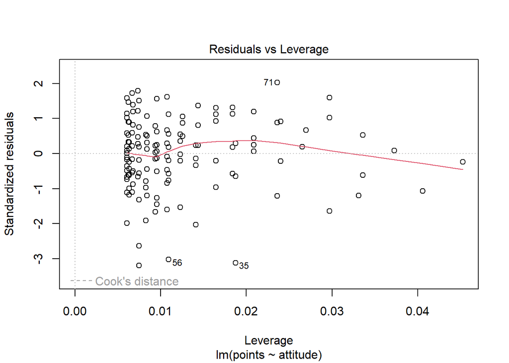

```r
plot(my_model3, which = 5)
```

## Explaining the assumptions behind the regression model (model3)

1. The data should be normally distributed. There are many ways to test/model this, but our previous histogram and Normal QQ-plot already tell us, that our residuals are fairly normally distributed, but there are some exceptions at the upper and lower ends.
2. One of the important assumptions in linear regression. It means that error remains constant along the values of the dependent variable. This means that there should not be a higher variance among students with a high/low attitude. We can check this with a residuals vs fitted plot. There the residuals are located randomly around 0-line, which suggest that our assumption of the linear relationship is reasonable.
3. Another important assumptions of the linear model is homoscedasticity , which means that the variance of our residuals stay the same independent of the explanatory variable. We can check this with a residuals vs fitted plot. The residuals roughly form a horisontal band close to the 0-line which suggest that the variances of the error terms are equal. However, three residuals stand out and they might be outliers.
4. Outliers can be looked out by our Residuals vs Leverage model. Points that have high residual and high leverage at the same my be harmful to our model and accuracy of our regression. None of the points seem to be out of Cook’s distance so we don’t seem to have significant outliers after all.

After all our model seems to be reasonably well fitted.